# Statistical Modeling

Xiaochi

18/09/2019

# Chapter 1 Introduction

```r
sqrt(25)
```

```
## [1] 5
```

```r
seq(3, 10)
```

```
## [1]  3  4  5  6  7  8  9 10
```

```r
seq(10,3)
```

```
## [1] 10  9  8  7  6  5  4  3
```

```r
seq(3,10,by=2)
```

```
## [1] 3 5 7 9
```

```r
date()
```

```
## [1] "Fri Jan  3 15:45:36 2020"
```

```r
x <- 16
x
```

```
## [1] 16
```

```r
x <- seq(1,7)
x
```

```
## [1] 1 2 3 4 5 6 7
```

# Chapter 2 Data in R

```r
head(Galton)
```

```
##   family father mother sex height nkids
## 1      1   78.5   67.0   M   73.2     4
## 2      1   78.5   67.0   F   69.2     4
## 3      1   78.5   67.0   F   69.0     4
## 4      1   78.5   67.0   F   69.0     4
## 5      2   75.5   66.5   M   73.5     4
## 6      2   75.5   66.5   M   72.5     4
```

```r
Swim <- read.csv("http://tiny.cc/mosaic/swim100m.csv")
```

```r
names(Swim)
```

```
## [1] "year" "time" "sex"
```

```r
summary(Swim)
```

```
##       year           time       sex
##  Min.   :1905   Min.   :47.84   F:31
##  1st Qu.:1924   1st Qu.:53.64   M:31
##  Median :1956   Median :56.88
##  Mean   :1952   Mean   :59.92
##  3rd Qu.:1976   3rd Qu.:65.20
##  Max.   :2004   Max.   :95.00
```

```r
mean(Swim$time)
```

```
## [1] 59.92419
```

```r
mean( ~ time, data = Swim)
```

```
## [1] 59.92419
```

```r
min( ~ time, data = Swim)
```

```
## [1] 47.84
```

```r
mean(time ~ sex, data = Swim )
```

```
##        F        M
## 65.19226 54.65613
```

```r
mean( Swim$time ~ Swim$sex )
```

```
##        F        M
## 65.19226 54.65613
```

```r
Swim$minutes = Swim$time/60
```

```r
head(Swim, n = 3L)
```

```
##   year time sex  minutes
## 1 1905 65.8   M 1.096667
## 2 1908 65.6   M 1.093333
## 3 1910 62.8   M 1.046667
```

```r
Swim$time = Swim$time/60
head(Swim, n = 3L)
```

```
##   year     time sex  minutes
## 1 1905 1.096667   M 1.096667
## 2 1908 1.093333   M 1.093333
## 3 1910 1.046667   M 1.046667
```

```r
Kids <- read.csv("http://tiny.cc/mosaic/kidsfeet.csv")
nrow(Kids)
```

```
## [1] 39
```

```r
deal(Kids, 5)
```

```
##        name birthmonth birthyear length width sex biggerfoot domhand
## 28    David         12        87   25.5   9.5   B          R       R
## 30   Dwayne          8        88   23.9   9.3   B          R       L
## 23    Laura          9        88   24.0   8.3   G          R       L
## 16     Kate          4        88   23.7   7.9   G          R       R
## 17 Caroline         12        87   24.0   8.7   G          R       L
##    orig.id
## 28      28
## 30      30
## 23      23
## 16      16
## 17      17
```

```r
resample(Kids, 5)
```

```
##      name birthmonth birthyear length width sex biggerfoot domhand orig.id
## 10  Damon          9        88   22.9   8.8   B          R       L      10
## 34  Dylan          4        88   23.6   9.0   B          R       L      34
## 3    Zach         12        87   24.5   9.7   B          R       R       3
## 18 Maggie          3        88   24.7   8.8   G          R       R      18
## 1   David          5        88   24.4   8.4   B          L       R       1
```

# Chapter 3 Describing Variation

```r
Galton = read.csv("http://tiny.cc/mosaic/galton.csv")
```

```r
mean( ~ height, data = Galton)
```

```
## [1] 66.76069
```

```r
median( ~ height, data = Galton)
```

```
## [1] 66.5
```

```r
sd( ~ height, data = Galton)
```

```
## [1] 3.582918
```

```r
var( ~ height, data = Galton)
```

```
## [1] 12.8373
```

```r
mean(Galton$height)
```

```
## [1] 66.76069
```

```r
median(Galton$height)
```

```
## [1] 66.5
```

```r
median(height ~ sex, data = Galton)
```

```
##    F    M
## 64.0 69.2
```

```r
pdata( ~ height, 63, data = Galton)
```

```
## [1] 0.1915367
```

```r
qdata( ~ height, 0.2, data = Galton)
```

```
##        p quantile
##      0.2     63.5
```

```r
qdata( ~ height, 0.5, data = Galton)
```

```
##        p quantile
##      0.5     66.5
```

```r
median( ~ height, data = Galton)
```

```
## [1] 66.5
```

```r
qdata( ~ height, c(0.25, 0.75), data = Galton)
```

```
##     quantile    p
## 25%     64.0 0.25
## 75%     69.7 0.75
```

```r
qdata( ~ height, c(0.025, 0.975), data = Galton)
```

```
##       quantile     p
## 2.5%        60 0.025
## 97.5%       73 0.975
```

```r
quantile(Galton$height, c(0.025, 0.975))
```

```
##  2.5% 97.5%
##    60    73
```

```r
IQR( ~ height, data = Galton)
```

```
## [1] 5.7
```

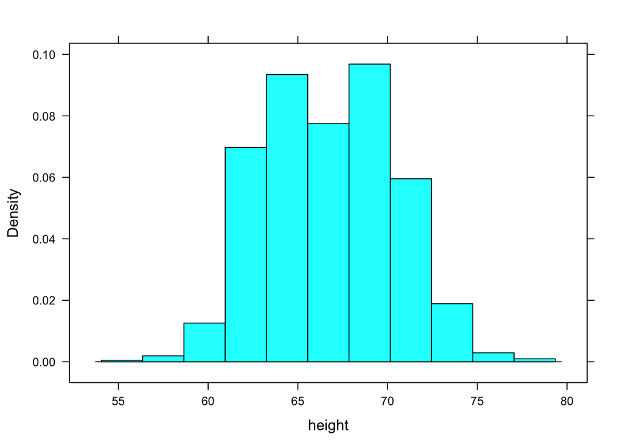

```r
histogram( ~ height, data = Galton)
```

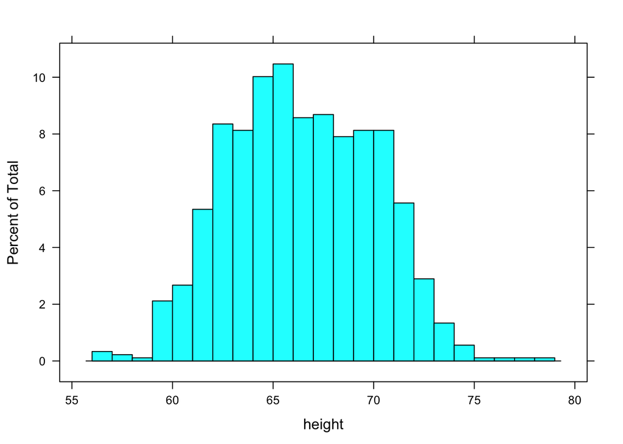

```r
histogram( ~ height, data = Galton, breaks = 25 )
```

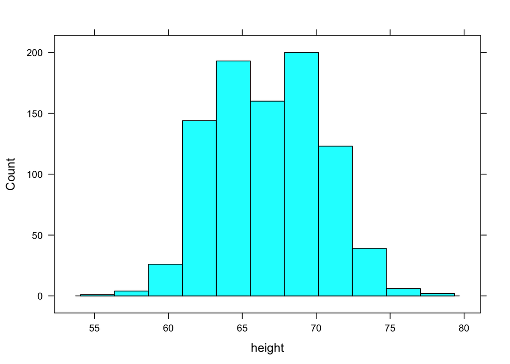

```r
histogram( ~ height, data = Galton, type = "count")
```

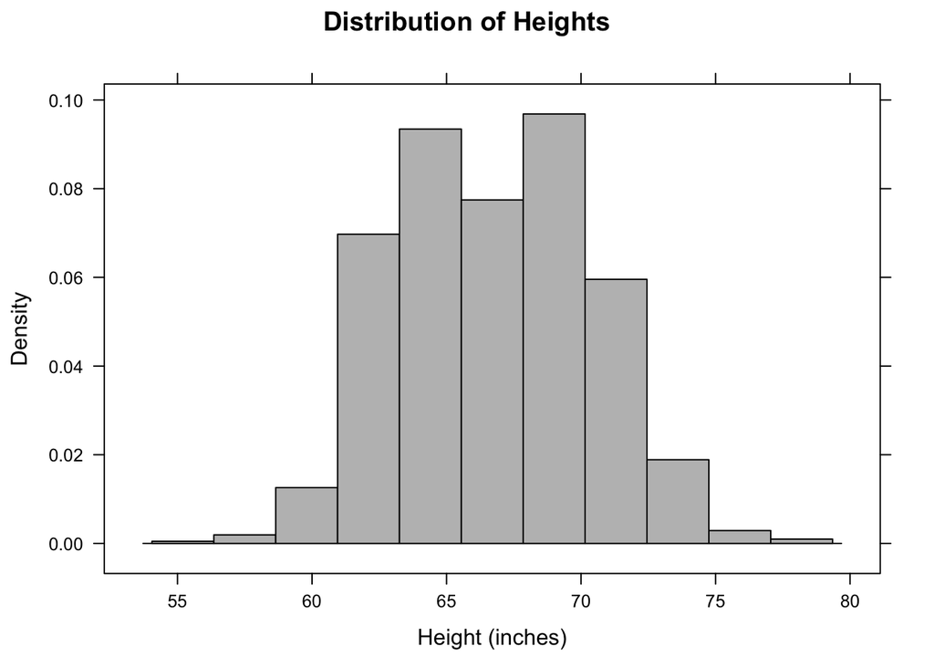

```r
histogram( ~ height, data = Galton, type = "density",
     xlab="Height (inches)",
     main="Distribution of Heights",
     col="gray")
```

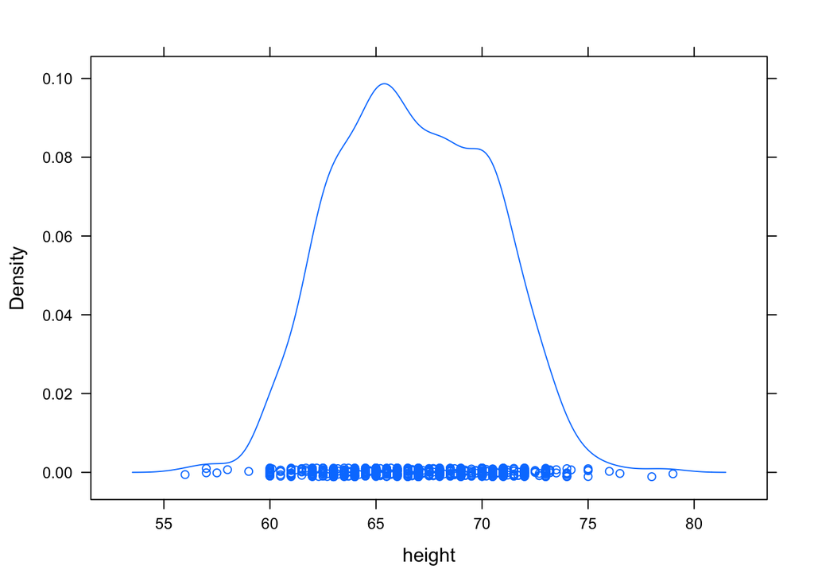

```r
densityplot( ~ height, data = Galton)
```

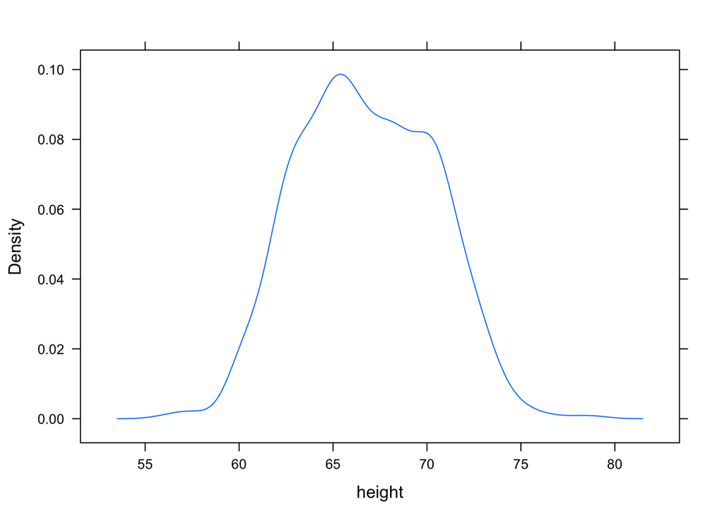

```r
densityplot( ~ height, data = Galton, plot.points = FALSE)
```

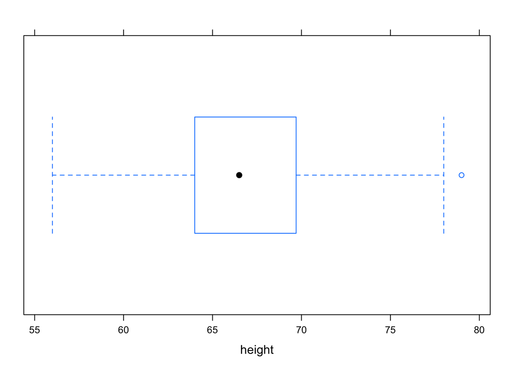

```r
bwplot( ~ height, data = Galton)
```

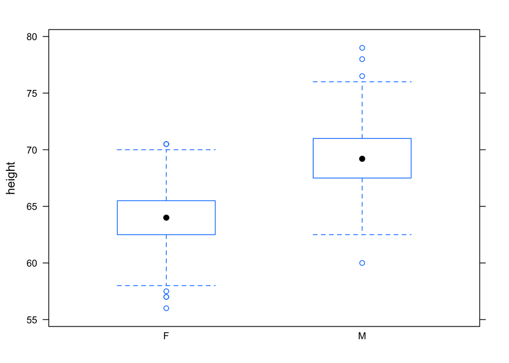

```r
bwplot(height ~ sex, data = Galton)
```

```r
tally( ~ sex, data = Galton)
```

```
## sex
##   F   M
## 433 465
```

```r
tally( ~ sex, data = Galton)/nrow(Galton)
```

```
## sex
##         F         M
## 0.4821826 0.5178174
```

# Chapter 4 Groupwise models

```r
Runners = read.csv("http://tiny.cc/mosaic/Cherry-Blossom-2008.csv")
```

```r
mean( gun ~ 1, data = Runners)
```

```
##        1
## 93.72504
```

```r
median(gun ~ 1, data = Runners )
```

```
##        1
## 93.68333
```

```r
sd( gun ~ 1, data = Runners )
```

```
##        1
## 14.96899
```

```r
mean(gun ~ sex, data = Runners)
```

```
##        F        M
## 98.77277 88.25673
```

```r
sd( gun ~ sex, data = Runners )
```

```
##        F        M
## 13.33713 14.71851
```

```r
CPS = read.csv("http://tiny.cc/mosaic/cps.csv")
```

```r
mean( wage ~ sector, data = CPS )
```

```
##  clerical     const     manag     manuf     other      prof     sales
##  7.422577  9.502000 12.704000  8.036029  8.500588 11.947429  7.592632
##   service
##  6.537470
```

```r
W <- read.csv("http://tiny.cc/mosaic/whickham.csv")
```

```r
levels(W$outcome)
```

```
## [1] "Alive" "Dead"
```

```r
W$ageGroups <- cut(W$age, breaks=c(0,30,40,53,64,75,100))
```

```r
Kids <- KidsFeet   # just get this from mosaicData instead of going out on the web with read.csv
```

# Chapter 5 Confidence intervals

```r
Runners = read.csv("http://tiny.cc/mosaic/Cherry-Blossom-2008.csv")
names( Runners )
```

```
## [1] "position" "division" "total"    "name"     "age"      "place"
## [7] "net"      "gun"      "sex"
```

```r
Mysamp = deal( Runners, 100 )
```

```r
mean( gun ~ sex, data = Mysamp )
```

```
##        F        M
## 97.48939 86.35407
```

```r
nums = c(1,2,3,4,5)
nums
```

```
## [1] 1 2 3 4 5
```

```r
resample(nums)
```

```
## [1] 3 5 2 5 1
```

```r
mean( gun ~ sex, data = resample(Mysamp) )
```

```
##        F        M
## 98.54889 86.21879
```

```r
mean( gun ~ sex, data = resample(Mysamp) )
```

```
##        F        M
## 97.92327 83.02021
```

```r
do(5) * mean( gun ~ sex, data = resample(Mysamp) )
```

```
##          F        M
## 1 97.10525 87.05290
## 2 99.24303 87.42519
## 3 98.73424 87.80185
## 4 95.34032 82.48904
## 5 97.74150 88.63333
```

```r
trials = do(500) * mean( gun ~ sex, data = resample(Mysamp) )
head(trials)
```

```
##           F        M
## 1  96.76090 87.92326
## 2  98.32611 85.68208
## 3  97.82688 85.51316
## 4 100.10249 83.40354
## 5  97.56319 87.02244
## 6  97.30865 87.06111
```

```r
confint(trials)
```

```
##   name    lower     upper level     method estimate
## 1    F 94.07345 100.91942  0.95 percentile 97.48939
## 2    M 82.28365  90.80228  0.95 percentile 86.35407
```

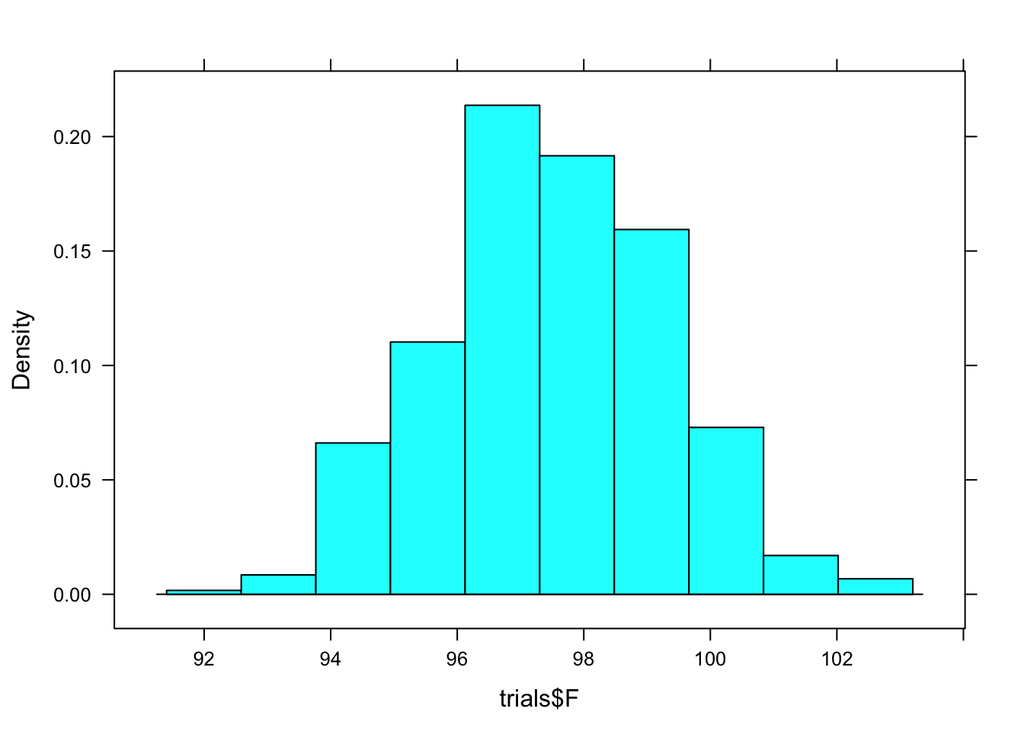

```r
histogram(trials$F)
```

```r
trials = do(500) * mean( gun ~ sex, data = deal(Runners, 100) )
confint(trials)
```

```
##   name    lower     upper level     method estimate
## 1    F 95.43946 102.50279  0.95 percentile 98.07258
## 2    M 83.74010  92.28496  0.95 percentile 89.34737
```

```r
Grades = read.csv("http://tiny.cc/mosaic/grades.csv")
gp = read.csv("http://tiny.cc/mosaic/grade-to-number.csv")
all.students = merge(Grades, gp)
one.student = subset( all.students, sid=="S31509" )
one.student
```

```
##      grade    sid   sessionID gradepoint
## 192      A S31509 session3443       4.00
## 543      A S31509 session2308       4.00
## 674      A S31509 session2851       4.00
## 1280     A S31509 session2737       4.00
## 1389     A S31509 session2585       4.00
## 1932    A- S31509 session2213       3.66
## 2666    A- S31509 session2562       3.66
## 4427    B+ S31509 session1959       3.33
## 4438    B+ S31509 session3036       3.33
## 5101    B+ S31509 session2928       3.33
## 5387    C+ S31509 session2344       2.33
## 5679     S S31509 session2764         NA
## 5902     S S31509 session2493         NA
```

```r
mean( ~ gradepoint, data=one.student )
```

```
## [1] NA
```

```r
GPAs <- mean( gradepoint ~ sid, data=all.students )
head(GPAs)
```

```
##   S31185   S31188   S31191   S31194   S31197   S31200
## 2.412500       NA       NA 3.359167 3.356154 2.186429
```

```r
trials = do(100)*mean( ~ gradepoint, data=resample(one.student), na.rm = TRUE )
```

```r
confint(trials)
```

```
##   name    lower    upper level     method estimate
## 1 mean 3.330475 3.860741  0.95 percentile 3.603636
```

# Chapter 6 Language of models

function * formula * graphs * tables

$$residuals = actual - model$$

the models (shown as smooth curves) suggest that wages increase until age 40, then level off.

wages tend to increase wiht age, up until about age 40, and they do so differently for men and for women and differently for married people and single people.

how gas usage depends on temperature

how wages depend on sex or marital status or age

gas usage can be expected to go down by 4 ccf for every degree of temperature increase

intercept term

main terms

interaction terms

transformation terms

Model terms are always about how the response variable depends on the explanatory variables, not how explanatory variables depend on one another.

An interaction term between two varaibles describes how two explanatory variables combine jointly to influence the response variable.

model design * response variable * explanatory variables * model terms

```r
Utils <- Utilities
```

```r
CPS <- CPS85
```

plot the response variable on the vertical axis and an explanatory variable on the horizontal axis.

## Quantitative Explanatory Variable

When the explanatory variable is quantitative, a scatter-plot is an appropriate graphical format. In the scatter plot, each case is a single point.

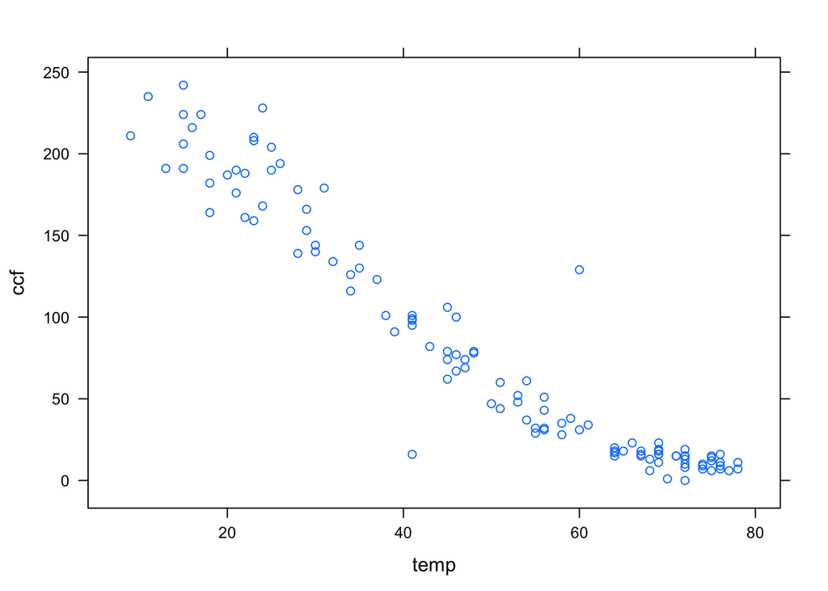

```r
xyplot( ccf ~ temp, data = Utils)
```

The first argument is a model formula written using the tilde modeling notation. This formula, ccf ~ temp is pronounced “ccf versus temperature.”

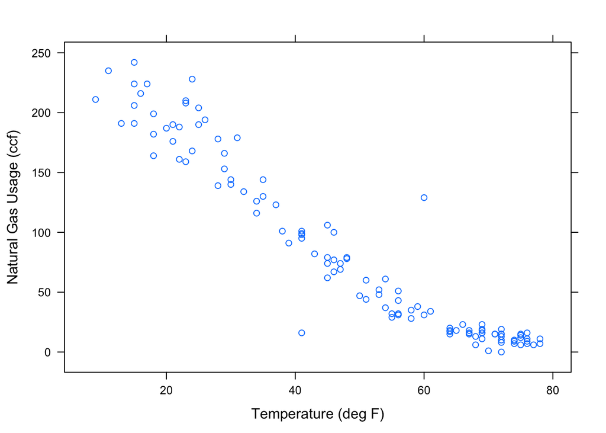

```r
xyplot( ccf ~ temp, data=Utils,
      xlab = "Temperature (deg F)",
      ylab = "Natural Gas Usage (ccf)")
```

## Categorical Explanatory Variable

When the explanatory variable is categorical, an appropriate format of display is the box-and-whiskers plot, made with the bwplot operator. Here, for example, is the wage versus sex from the Current Population Survey:

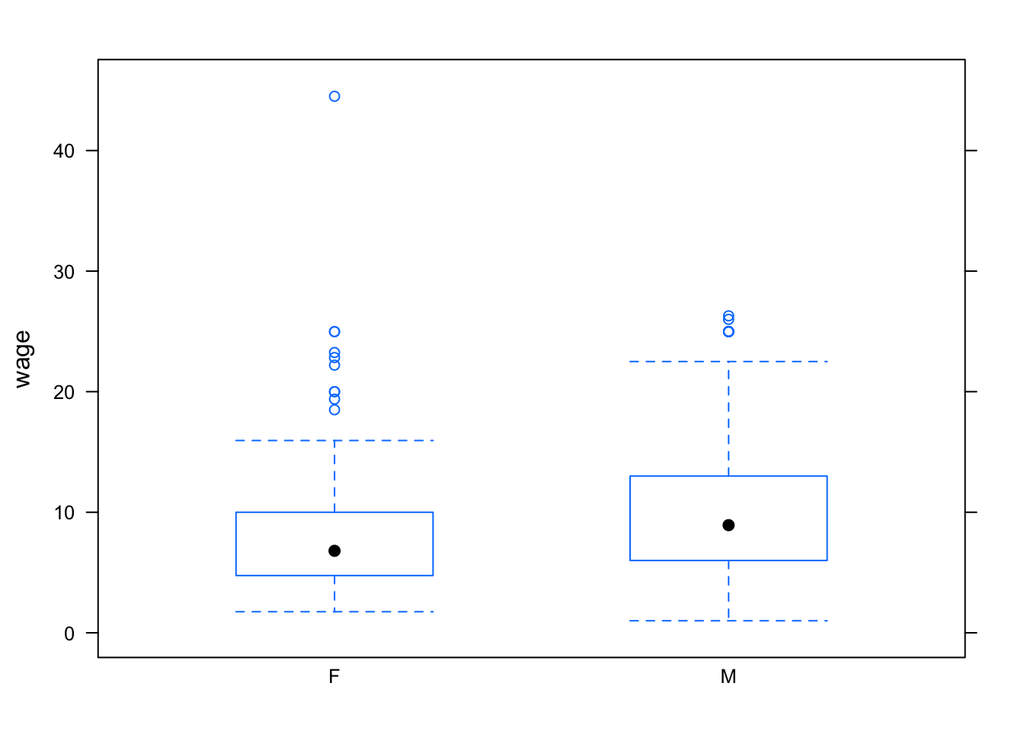

```r
bwplot( wage ~ sex, data=CPS)
```

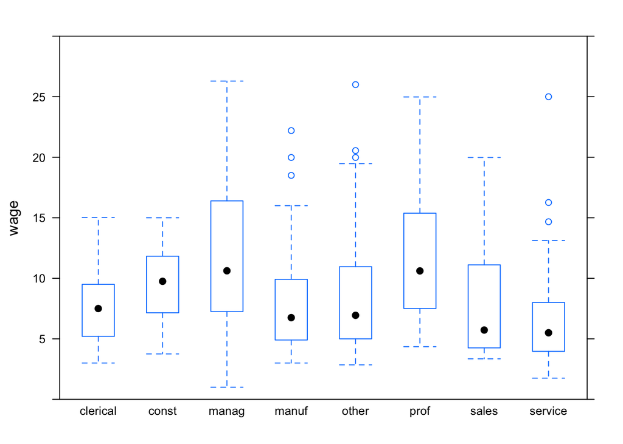

```r
bwplot(wage~sector, data=CPS, ylim=c(0,30))
```

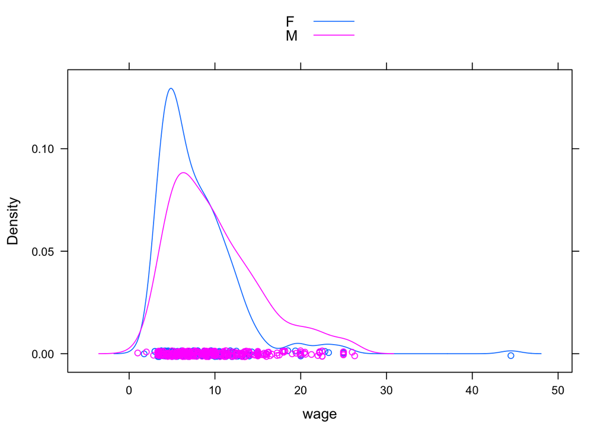

```r
densityplot(~ wage, groups = sex, data = CPS, auto.key = TRUE)
```

## Multiple Explanatory Variables

- Coding the additional explanatory variable] using color or symbol shapes. This is done by using the groups argument set to the name of the additional explanatory variable. For example:

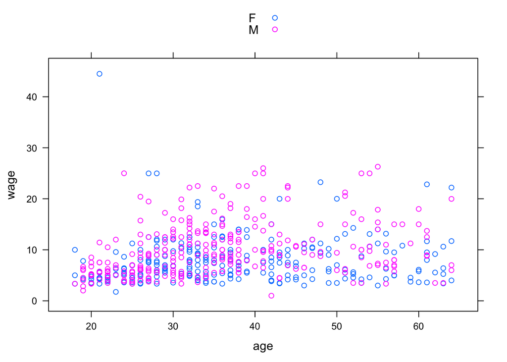

```r
xyplot( wage ~ age, groups = sex, data = CPS, auto.key = TRUE)
```

- Splitting the plot into the groups defined by the additional explanatory variable. This is done by including the additional variable in the model formula using a | separator.

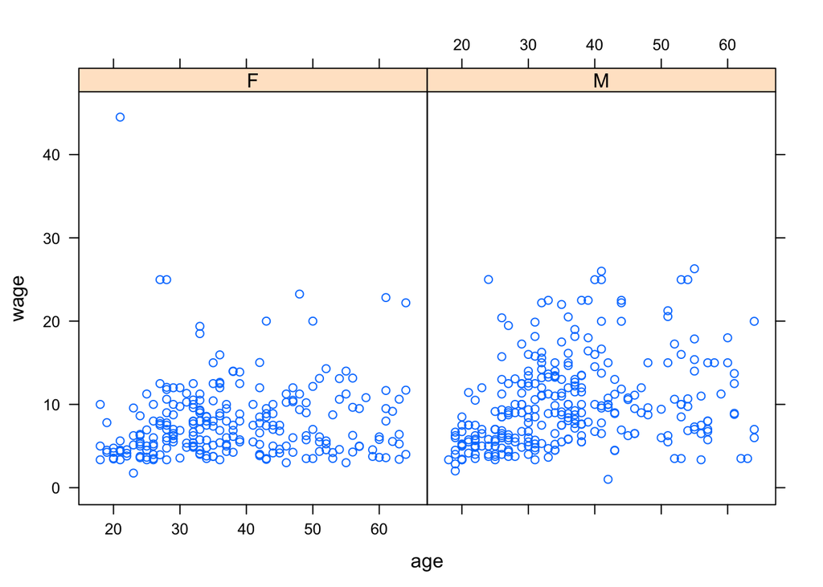

```r
xyplot( wage ~ age | sex, data = CPS)
```

## Fitting Models and Finding Model Values

The lm operator (short for “Linear Model”) will translate a model design into fitted model values.

```r
Swim <- read.csv("http://tiny.cc/mosaic/swim100m.csv")
```

```r
mod1 <- lm(time ~ 1, data = Swim)
```

Once the model has been constructed, the fitted values can be found using the fitted operator:

```r
fitted(mod1)
```

```
##        1        2        3        4        5        6        7        8
## 59.92419 59.92419 59.92419 59.92419 59.92419 59.92419 59.92419 59.92419
##        9       10       11       12       13       14       15       16
## 59.92419 59.92419 59.92419 59.92419 59.92419 59.92419 59.92419 59.92419
##       17       18       19       20       21       22       23       24
## 59.92419 59.92419 59.92419 59.92419 59.92419 59.92419 59.92419 59.92419
##       25       26       27       28       29       30       31       32
## 59.92419 59.92419 59.92419 59.92419 59.92419 59.92419 59.92419 59.92419
##       33       34       35       36       37       38       39       40
## 59.92419 59.92419 59.92419 59.92419 59.92419 59.92419 59.92419 59.92419
##       41       42       43       44       45       46       47       48
## 59.92419 59.92419 59.92419 59.92419 59.92419 59.92419 59.92419 59.92419
##       49       50       51       52       53       54       55       56
## 59.92419 59.92419 59.92419 59.92419 59.92419 59.92419 59.92419 59.92419
##       57       58       59       60       61       62
## 59.92419 59.92419 59.92419 59.92419 59.92419 59.92419
```

Plot out both the data values and the model values versus year just to emphasize that the model values are the same for every case:

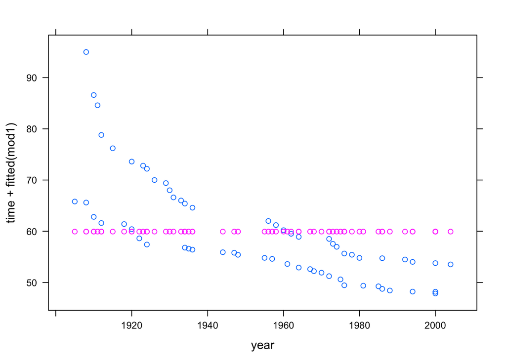

```r
xyplot(time + fitted(mod1) ~ year, data = Swim)
```

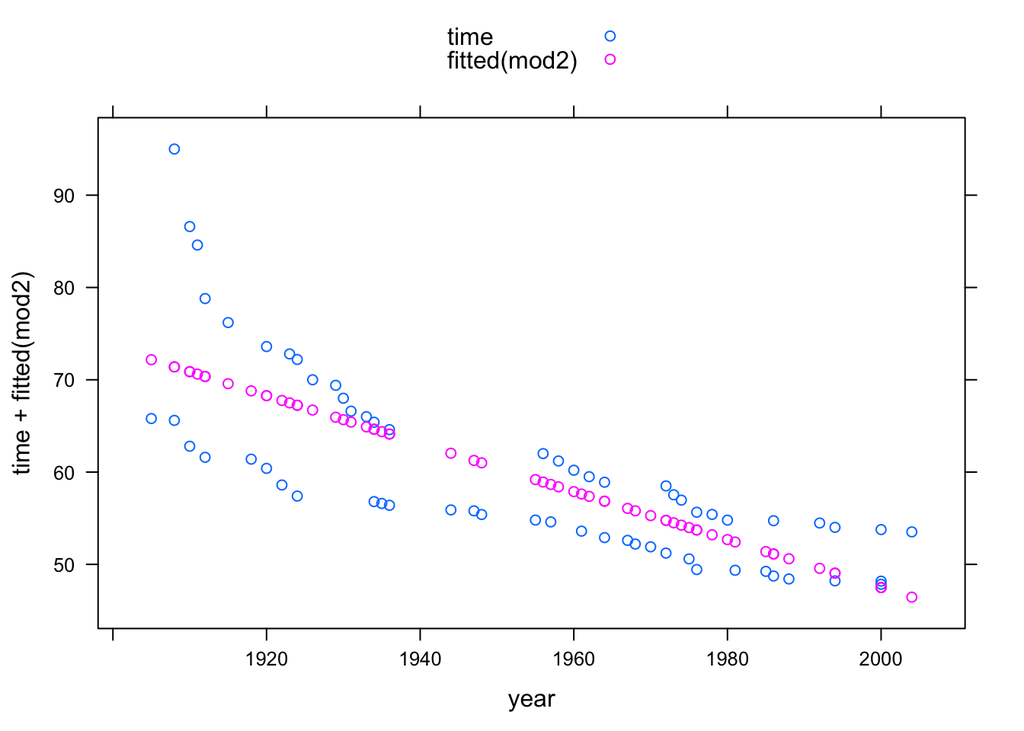

```r
mod2 <- lm( time ~ 1 + year, data = Swim)
xyplot(time + fitted(mod2) ~ year, data = Swim, auto.key = TRUE)
```

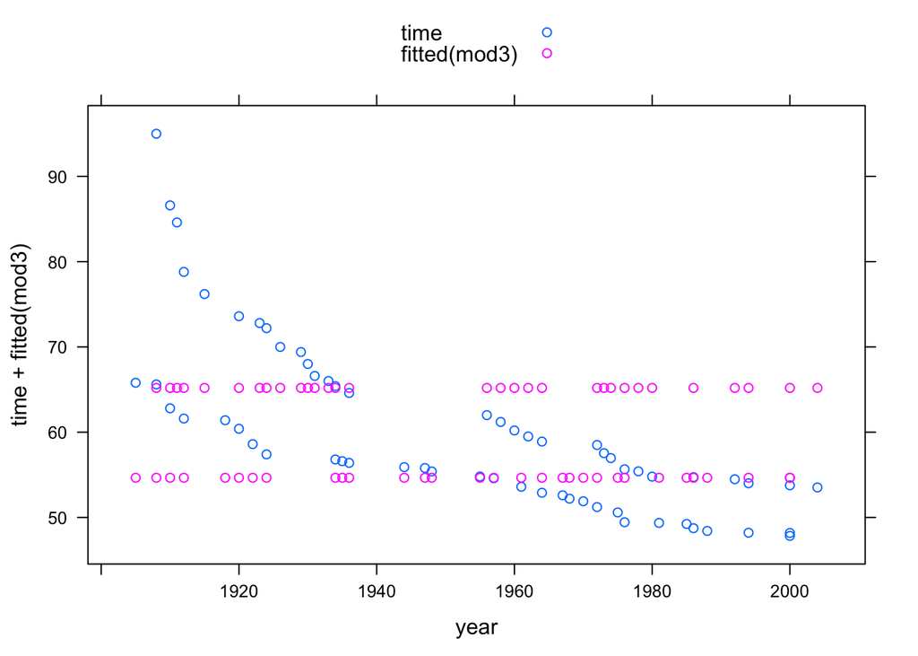

```r
mod3 <- lm( time ~ 1 + sex, data = Swim)
xyplot(time + fitted(mod3) ~ year, data = Swim, auto.key = TRUE)
```

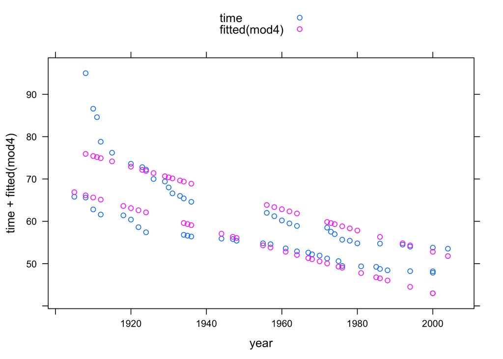

```r
mod4 <- lm( time ~ 1 + sex + year, data = Swim)
xyplot(time + fitted(mod4) ~ year, data = Swim, auto.key = TRUE)
```

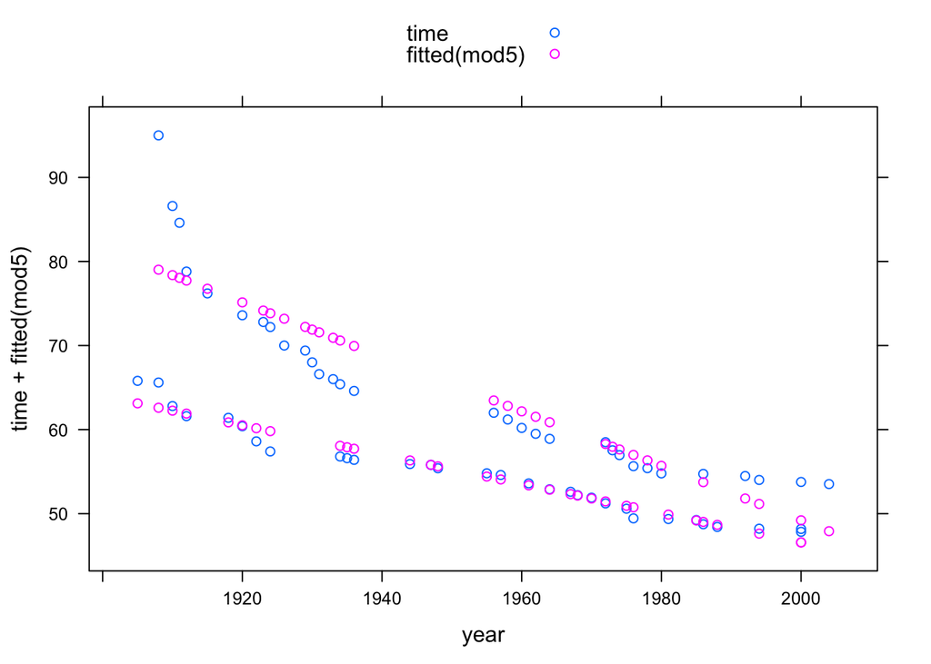

```r
mod5 <- lm( time ~ 1 + year + sex + year:sex, data = Swim)
xyplot(time + fitted(mod5) ~ year, data = Swim, auto.key = TRUE)
```

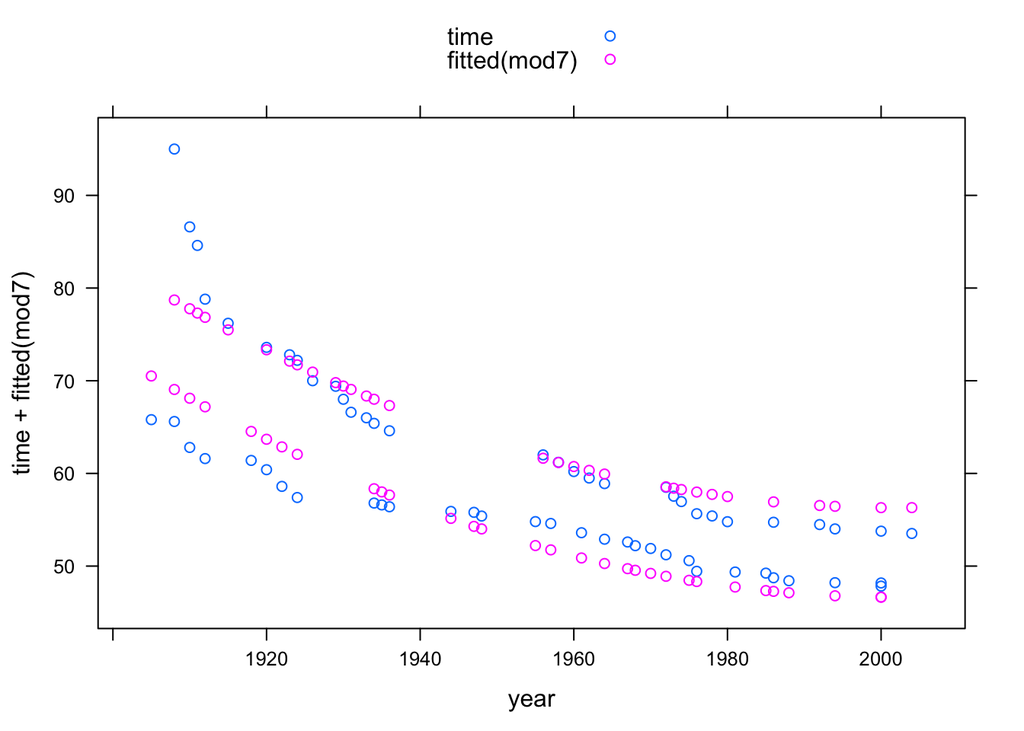

```r
mod7 <- lm( time ~ year + I(year^2) + sex, data = Swim)
xyplot(time + fitted(mod7) ~ year, data = Swim, auto.key = TRUE)
```

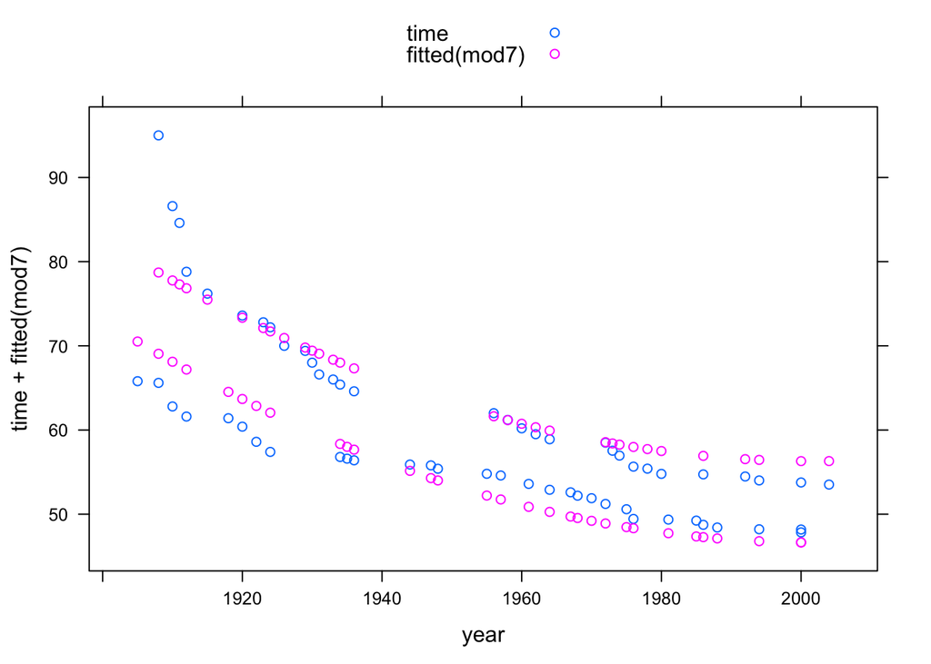

```r
mod7 <- lm( time ~ poly(year, 2) + sex, data = Swim)
xyplot(time + fitted(mod7) ~ year, data = Swim, auto.key = TRUE)
```

# Chapter 7 Model formulas and coefficients

model design

model formula: takes each of the terms in the model design and multiplies it by a number, model coefficient. Each of the terms has its own coefficient.

an extra inch of mother’s height is associated with an extra 0.283 inches in the child

$$height = 132.3 - 1.43mother - 1.21father + 0.0247father*mother$$

$$height = 15.3 + 0.322mother + 0.406father + 5.23sexM$$

a one-inch increase in fatehr leads to a 0.406 increase in the model value of height.

a one-inch change in mother will correspond to a 0.322 increase in the model value of height.

derivative: making a small change in the explanatory variable and seeing hwo much the model value changes.

a one-year increase in the amount of education that a worker received is associated with a 74 cents per hour increase in wages.

strategy for finding effective models: * fit a model that matches what you know about the system * check how good the fit is * try refining the model, adding detail by including curvy transformation terms * check the fit again and see if the improvement in the fit goes beyond what would be expected from chance.

a reasonable strategy * include only main terms * add in some interaction terms * try transformation terms

## Examining model coefficients

```r
SwimRecords
```

```
##    year  time sex
## 1  1905 65.80   M
## 2  1908 65.60   M
## 3  1910 62.80   M
## 4  1912 61.60   M
## 5  1918 61.40   M
## 6  1920 60.40   M
## 7  1922 58.60   M
## 8  1924 57.40   M
## 9  1934 56.80   M
## 10 1935 56.60   M
## 11 1936 56.40   M
## 12 1944 55.90   M
## 13 1947 55.80   M
## 14 1948 55.40   M
```

[output cut: 48 more lines]

lm() operator finds model coefficients

```r
mod <- lm( time ~ year + sex, data = SwimRecords)
```

```r
coef(mod)
```

```
## (Intercept)        year        sexM
## 555.7167834  -0.2514637  -9.7979615
```

```r
555.7 - 0.2515*2010 - 9.798
```

```
## [1] 40.387
```

the “value” used to multiply the intercept is always 1

the “value” used for a categorical level is either 0 or 1 depending on whether there is a match with the level

```r
summary(mod)
```

```
##
## Call:
## lm(formula = time ~ year + sex, data = SwimRecords)
##
## Residuals:
##     Min      1Q  Median      3Q     Max
## -4.7027 -2.7027 -0.5968  1.2796 19.0759
##
## Coefficients:
##              Estimate Std. Error t value Pr(>|t|)
## (Intercept) 555.71678   33.79991  16.441  < 2e-16 ***
## year         -0.25146    0.01732 -14.516  < 2e-16 ***
## sexM         -9.79796    1.01287  -9.673 8.79e-14 ***
## ---
## Signif. codes:  0 '***' 0.001 '**' 0.01 '*' 0.05 '.' 0.1 ' ' 1
##
## Residual standard error: 3.983 on 59 degrees of freedom
## Multiple R-squared:  0.844,  Adjusted R-squared:  0.8387
## F-statistic: 159.6 on 2 and 59 DF,  p-value: < 2.2e-16
```

When a model includes interaction terms, the interaction coefficients need to be multiplied by all the values involved in the interaction.

```r
mod2 <- lm( time ~ year * sex, data = SwimRecords)
coef(mod2)
```

```
##  (Intercept)         year         sexM    year:sexM
##  697.3012156   -0.3240459 -302.4638388    0.1499166
```

```r
697.3 - 0.3240 * 2010 - 302.5 + 0.1499 * 2010 * 1
```

```
## [1] 44.859
```

## Other Useful Operators

- cross() will combine two categorical variables into a single variable.

```r
CPS <- CPS85  # from mosaicData
RaceSex <- cross(CPS$sex, CPS$race)
summary(RaceSex)
```

```
## F:NW  F:W M:NW  M:W
##   28  217   39  250
```

- as.factor() will convert a quantitative variable to a categorical variable.

```r
utils <- read.csv("http://tiny.cc/mosaic/utilities.csv")
```

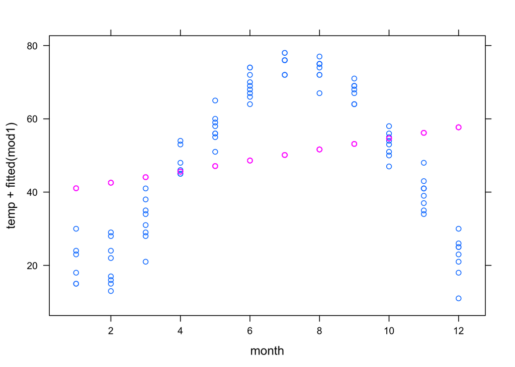

```r
mod1 <- lm(temp ~ month, data = utils)
xyplot(temp + fitted(mod1) ~ month, data = utils)
```

month is treated quantitatively, so the model term month produces a straight-line relationship that does not correspond well to the data.

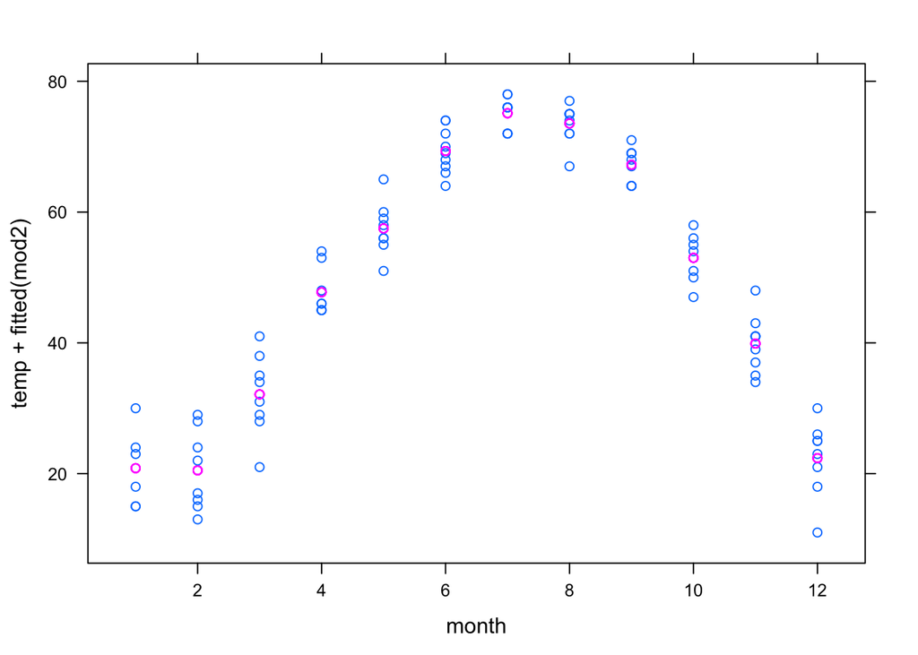

```r
mod2 <- lm(temp ~ as.factor(month), data = utils)
xyplot(temp + fitted(mod2) ~ month, data = utils )
```

In the second model, month is treated categorically, allowing a more complicated model relationship. In fact, this is a groupwise model: the model values represent the mean temperature for each month.

# Chapter 8 Fitting models to data

vectors were presented as a column of numbers

arrow: a direction and a length

Computing the fitted model values and the residuals is done with the fitted and resid.

```r
Swim <- SwimRecords  # from mosaicData
```

```r
mod1 <- lm(time ~ year + sex, data = Swim)
```

Once you have constructed the mdoel, you can use fitted and resid:

```r
modvals <- fitted(mod1)
head(modvals)
```

```
##        1        2        3        4        5        6
## 66.88051 66.12612 65.62319 65.12026 63.61148 63.10855
```

```r
residvals <- resid(mod1)
head(residvals)
```

```
##          1          2          3          4          5          6
## -1.0805086 -0.5261176 -2.8231902 -3.5202629 -2.2114808 -2.7085534
```

## Sums of Squares

```r
mean(fitted(mod1))
```

```
## [1] 59.92419
```

```r
var(resid(mod1))
```

```
## [1] 15.34147
```

```r
sd(resid(mod1))
```

```
## [1] 3.916818
```

```r
summary(resid(mod1))
```

```
##    Min. 1st Qu.  Median    Mean 3rd Qu.    Max.
## -4.7027 -2.7027 -0.5968  0.0000  1.2796 19.0759
```

Sums of squares are very important in statistics.

```r
sum(Swim$time^2)
```

```
## [1] 228635
```

```r
sum(fitted(mod1)^2)
```

```
## [1] 227699.2
```

```r
sum(resid(mod1)^2)
```

```
## [1] 935.8294
```

The partitioning of variation by models is seen by the way the sum of squares of the fitted and the residuals add up to the sum of squares of the response

```r
sum(fitted(mod1)^2) + sum(resid(mod1)^2)
```

```
## [1] 228635
```

```r
sum(Swim$time^2)
```

```
## [1] 228635
```

Don’t forget the squaring stage of the operation

```r
sum(resid(mod1))
```

```
## [1] 1.848521e-14
```

```r
sum(resid(mod1)^2)
```

```
## [1] 935.8294
```

## Redundancy

```r
Swim$afterwar <- Swim$year - 1945
```

```r
mod1 <- lm( time ~ year + sex, data = Swim)
```

When the redundant variable is added in, lm successfully detects the redundancy and handles it. This is indicated by a coefficient of NA on the redundant variable.

```r
mod2 <- lm( time ~ year + sex + afterwar, data = Swim)
```

```r
mod3 <- lm( time ~ afterwar + year + sex, data = Swim)
```

```r
head(fitted(mod2))
```

```
##        1        2        3        4        5        6
## 66.88051 66.12612 65.62319 65.12026 63.61148 63.10855
```

```r
head(fitted(mod3))
```

```
##        1        2        3        4        5        6
## 66.88051 66.12612 65.62319 65.12026 63.61148 63.10855
```

Note that whenever you use a categorical variable and an intercept term in a model, there is a redundancy.

```r
mod <- lm(time ~ sex - 1, data = Swim)
```

```r
mod <- lm(time ~ sex, data = Swim)
```

# Chapter 9 Correlation and partitioning of variation

$$R^2 = \frac{variance \ of \ fitted \ model \ values}{variance \ of \ response \ values}$$

coefficient of determination

correlation coefficient

The coefficient of determination, $R^2$, compares the variation in the response variable to the variation in the fitted model value.

```r
Swim <- SwimRecords # from mosaicData
```

```r
mod <- lm(time ~ year + sex, data = Swim)
```

```r
var(fitted(mod)) / var(Swim$time)
```

```
## [1] 0.8439936
```

```r
rsquared(mod)
```

```
## [1] 0.8439936
```

The regression report is a standard way of summarizing models. Such a report is produced by most statistical software packages and used in many fields. The $R^2$ statistic is a standard part of the report; look at the second line from the bottom.

```r
summary(mod)
```

```
##
## Call:
## lm(formula = time ~ year + sex, data = Swim)
##
## Residuals:
##     Min      1Q  Median      3Q     Max
## -4.7027 -2.7027 -0.5968  1.2796 19.0759
##
## Coefficients:
##              Estimate Std. Error t value Pr(>|t|)
## (Intercept) 555.71678   33.79991  16.441  < 2e-16 ***
## year         -0.25146    0.01732 -14.516  < 2e-16 ***
## sexM         -9.79796    1.01287  -9.673 8.79e-14 ***
## ---
## Signif. codes:  0 '***' 0.001 '**' 0.01 '*' 0.05 '.' 0.1 ' ' 1
##
## Residual standard error: 3.983 on 59 degrees of freedom
## Multiple R-squared:  0.844,  Adjusted R-squared:  0.8387
## F-statistic: 159.6 on 2 and 59 DF,  p-value: < 2.2e-16
```

```r
mod2 <- lm(time ~ year, data = Swim)
```

```r
sqrt(rsquared(mod2))
```

```
## [1] 0.7723752
```

```r
cor(Swim$time, Swim$year)
```

```
## [1] -0.7723752
```

# Chapter 10 Total and Partial Change

The term partial relationship describes a relationship with one or more covariates being held constant.

In contrast to a partial relationship where certain variables are being held constant, there is also a total relationship: how an explanatory variable is related to a response variable letting those other explanatory variables change as they will.

## Adjustment

```r
Cps <- CPS85
```

```r
mod0 <- lm( wage ~ sex, data = Cps)
summary(mod0)
```

```
##
## Call:
## lm(formula = wage ~ sex, data = Cps)
##
## Residuals:
##    Min     1Q Median     3Q    Max
## -8.995 -3.529 -1.072  2.394 36.621
##
## Coefficients:
##             Estimate Std. Error t value Pr(>|t|)
## (Intercept)   7.8789     0.3216   24.50  < 2e-16 ***
## sexM          2.1161     0.4372    4.84  1.7e-06 ***
## ---
## Signif. codes:  0 '***' 0.001 '**' 0.01 '*' 0.05 '.' 0.1 ' ' 1
##
## Residual standard error: 5.034 on 532 degrees of freedom
## Multiple R-squared:  0.04218,    Adjusted R-squared:  0.04038
## F-statistic: 23.43 on 1 and 532 DF,  p-value: 1.703e-06
```

The coefficients indicate that a typical male makes $2.12 more per hour than a typical female. (Notice that R2=0.0422 is very small: sex explains hardly any of the person-to-person variability in wage.)

By including the variables age, educ, and sector in the model, you can adjust for these variables:

```r
mod1 <- lm( wage ~ age + sex + educ + sector, data = Cps)
summary(mod1)
```

```
##
## Call:
## lm(formula = wage ~ age + sex + educ + sector, data = Cps)
##
## Residuals:
##     Min      1Q  Median      3Q     Max
## -11.198  -2.695  -0.465   2.066  35.159
##
## Coefficients:
##               Estimate Std. Error t value Pr(>|t|)
## (Intercept)   -4.69411    1.53776  -3.053 0.002384 **
## age            0.10221    0.01657   6.167 1.39e-09 ***
## sexM           1.94172    0.42285   4.592 5.51e-06 ***
## educ           0.61556    0.09439   6.521 1.65e-10 ***
## sectorconst    1.43552    1.13120   1.269 0.204999
## sectormanag    3.27105    0.76685   4.266 2.37e-05 ***
## sectormanuf    0.80627    0.73115   1.103 0.270644
## sectorother    0.75838    0.75918   0.999 0.318286
## sectorprof     2.24777    0.66976   3.356 0.000848 ***
## sectorsales   -0.76706    0.84202  -0.911 0.362729
## sectorservice -0.56871    0.66602  -0.854 0.393556
## ---
## Signif. codes:  0 '***' 0.001 '**' 0.01 '*' 0.05 '.' 0.1 ' ' 1
##
## Residual standard error: 4.334 on 523 degrees of freedom
## Multiple R-squared:  0.3022, Adjusted R-squared:  0.2888
## F-statistic: 22.65 on 10 and 523 DF,  p-value: < 2.2e-16
```

The adjusted difference between the sexes is $1.94 per hour. (The R2=0.30 from this model is considerably larger than for mod0, but still a lot of the person-to-person variation in wages has not be captured.)

It would be wrong to claim that simply including a covariate in a model guarantees that an appropriate adjustment has been made. The effectiveness of the adjustment depends on whether the model design is appropriate, for instance whether appropriate interaction terms have been included. However, it’s certainly the case that if you don’t include the covariate in the model, you have not adjusted for it.

The other approach is to subsample the data so that the levels of the covariates are approximately constant.

```r
small <- subset(Cps, age <=35 & age >= 30 & educ>=10 & educ <=12 & sector=="sales" )
```

```r
mod4 <- lm( wage ~ sex, data = small)
summary(mod4)
```

```
##
## Call:
## lm(formula = wage ~ sex, data = small)
##
## Residuals:
##   10  156  195
##  0.5  0.0 -0.5
##
## Coefficients:
##             Estimate Std. Error t value Pr(>|t|)
## (Intercept)    4.500      0.500   9.000   0.0704 .
## sexM           4.500      0.866   5.196   0.1210
## ---
## Signif. codes:  0 '***' 0.001 '**' 0.01 '*' 0.05 '.' 0.1 ' ' 1
##
## Residual standard error: 0.7071 on 1 degrees of freedom
## Multiple R-squared:  0.9643, Adjusted R-squared:  0.9286
## F-statistic:    27 on 1 and 1 DF,  p-value: 0.121
```

# Chapter 11 Modeling Randomness

```r
coin <- c("H","T")
resample(coin, 5)
```

```
## [1] "T" "T" "H" "T" "T"
```

```r
die <- seq(1,6)
die
```

```
## [1] 1 2 3 4 5 6
```

```r
resample(die,2)
```

```
## [1] 2 3
```

## Random Draws from Probability Models

```r
resample( coin, 10, prob = c(.9,.1))
```

```
##  [1] "H" "H" "H" "H" "T" "H" "H" "H" "H" "H"
```

the rnorm() function makes random draws from a normal probability distribution.

- The required argument tells how many draws to make.
- Optional, named arguments let you specify the mean and standard deviation of the particular normal distribution that you want.

```r
samps <- rnorm(15, mean = 1000, sd = 75)
samps
```

```
##  [1] 1009.7198  994.7648  975.0633 1033.4814  909.2640  885.5522  994.7032
##  [8] 1111.8322  991.6604 1065.1789 1081.9568 1068.4842  995.8265  961.6602
## [15] 1005.9065
```

```r
mean(samps)
```

```
## [1] 1005.67
```

```r
sd(samps)
```

```
## [1] 61.23453
```

```r
samps <- rnorm(100000, mean = 1000, sd = 75)
mean( samps )
```

```
## [1] 999.9737
```

```r
sd(samps)
```

```
## [1] 74.93002
```

```r
samps <- rbinom(40, size = 3, prob = 0.63)
samps
```

```
##  [1] 2 3 2 3 1 0 3 3 1 2 1 2 2 2 3 2 2 1 0 3 0 1 3 2 1 2 1 2 1 2 2 2 2 2 2
## [36] 1 1 3 2 3
```

```r
table(samps)
```

```
## samps
##  0  1  2  3
##  3 10 18  9
```

```r
rpois(25, lambda = 15)
```

```
##  [1] 14 12 14 17 17 13 10 12 18 15  6 14 17 13 11 11 15 14 22 13 11 19 18
## [24] 17 14
```

```r
rexp( 15, rate = 0.03 )
```

```
##  [1] 24.5832513 12.0844849  4.0139309 80.8046420 79.7442252  9.5118461
##  [7] 48.1865367 86.4203469 84.4906516 40.3511955  0.7290076  2.1685519
## [13] 14.7343037 76.1084204 14.7710594
```

## Quantiles and Coverage Intervals

You will often need to compute coverage intervals in order to describe the range of likely outcomes from a random process.

```r
qnorm( c(0.025, 0.975), mean = 0, sd = 1)
```

```
## [1] -1.959964  1.959964
```

```r
qbinom( c(0.025, 0.975), size = 3, prob = 0.63)
```

```
## [1] 0 3
```

```r
qpois( c(0.025, 0.975), lambda = 15)
```

```
## [1]  8 23
```

```r
qexp( c(.025, .975), rate = 0.03)
```

```
## [1]   0.8439269 122.9626485
```

```r
qexp( .25, rate = 0.03)
```

```
## [1] 9.589402
```

```r
samps <- rnorm(10000, mean = 0, sd = 1)
qdata( samps, c(.025, .975) )
```

```
##        quantile     p
## 2.5%  -2.016786 0.025
## 97.5%  1.905258 0.975
```

## Percentiles

Percentile (e.g. pnorm) The input argument is a measured value, something that could be the output of a single draw from the probability distribution. The output is always a number between 0 and 1 — a percentile.

Quantile (e.g. qnorm) The input is a percentile, a number between 0 and 1. The output is on the scale of the measured variable.

```r
pnorm(670, mean = 600, sd = 100)
```

```
## [1] 0.7580363
```

```r
qnorm(0.85, mean = 600, sd = 100)
```

```
## [1] 703.6433
```